# **REKURSIF**

**Beberapa permasalahan tertentu terkadang membutuhkan penyelesaian dengan cara perulangan, misalkan permasalahan pengurutan, perhitungan deret, dan sebagainya. Terdapat dua metode untuk menyelesaikan permasalahan tersebut, yaitu :**

1. Iteratif
2. Rekursif
3. Implementasi Rekursif
4. Visualisasi Fraktal

Iteratif Iteratif merupakan penyelesaian permasalahan dengan perulangan, menggunakan syntax for atau while (pada Python). Misalkan permasalahan perhitungan faktorial suatu bilangan, yaitu : 5! = 5x4x3x2x1 , atau n! = n x (n - 1) x (n - 2) x (n - 3)x...

maka perhitungan faktorial suatu bilangan dapat dilakukan dengan cara iterasi, yaitu mengmenghitung operasi perkalian mulai dari bilangan tersebut sampai dengan satu.

Code Berikut adalah code untuk perhitungan faktorial suatu bilangan dengan menggunakan cara iteratif. Pada code ini, terdapat iterasi while, yang menghitung perkalian, mulai dari , sampai dengan 2.

```python
def factorialIteratif(bilangan):
    if bilangan <=1:
        return(1)
    else:
        temp=bilangan
        hasil=1
        while temp>1:
            hasil=hasil*temp
            temp=temp-1
        return(hasil)

print(factorialIteratif(4))
```

Suatu permasalahan akan lebih mudah dipecahkan jika permasalahan tersebut berukuran kecil. Misalkan pengurutan data akan lebih mudah dilakukan jika data yang diurutkan hanya terdiri dari dua buah data saja, sehingga pengurutan dapat dilakukan dengan membandingkan dua data tersebut saja. Rekursif merupakan suatu teknik pemrograman yang memecah permasalahan menjadi permasalahan dengan ukuran yang lebih kecil dan lebih kecil lagi, sehingga permasalahan dengan ukuran kecil tersebut dapat dengan mudah dipecahkan. Teknik ini dapat dilakukan dengan cara memanggil fungsi itu sendiri.

Jika pada contoh sebelumnya, untuk menghitung suatu bilangan dapat dilakukan dengan menggunakan cara iterasi, maka berikut ini adalah penyelesaian perhitungan faktorial dengan cara rekursif.

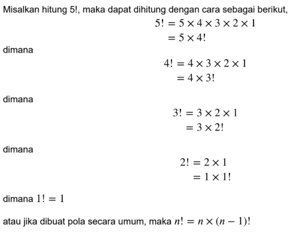

```python
def factorialRekursif(bilangan):
    if bilangan <=1:
        return(1)
    else:
        return(bilangan * factorialRekursif(bilangan-1))
        data=factorialRekursif(4)
print(data)
```

Dari fungsi tersebut dapat dilihat bahwa teknik pemrograman rekursif ini melibatkan pemanggilan fungsinya itu sendiri dengan argument atau parameter yang berukuran lebih kecil. Berikut beberapa aturan dalam teknik pemrograman rekursif:

- Fungsi rekursif harus memiliki base case, base case inilah yang berfungsi untuk menghentikan pemanggilan terus menerus fungsi rekursif
- fungsi rekursif harus memiliki sintaks yang dapat merubah state dari permasalahan, sehingga semakin lama solusi permasalahan menuju base case yang sudah dibuat
- Fungsi rekursif harus memanggil dirinya sendiri

## **Implementasi Rekursif**

Banyak permasalahan yang dapat diselesaikan dengan teknik pemrograman rekursif ini. Berikut contoh-contoh implementasi rekursif.

## **Triangular Numbers**

Terdapat deret bilangan berikut : 1, 3, 6, 10, 15, 21, 28, 36, ... Bagaimanakah pola bilangan tersebut ? Deret bilangan tersebut dikenal dengan nama Triangular Numbers, yang dapat diilustrasikan seperti Gambar 1 berikut.

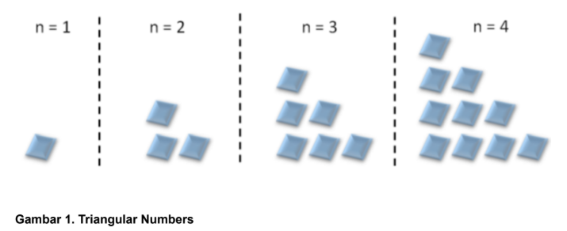

Bagaimana menentukan bilangan ke- dari deret tersebut ? Ilustrasi perhitungan deret keempat dari triangular numbers dapat dilihat pada Gambar 2 berikut:

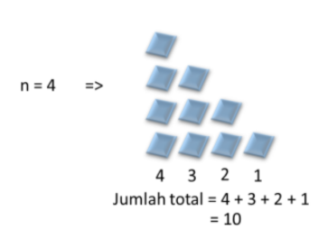

**Gambar 2. Perhitungan Triangular Numbers**

Dapat dilihat pada Gambar tersebut bahwa kolom pertama memiliki 4 kotak, kolom kedua memiliki 3 kotak, kolom ketiga memiliki 2 kotak, dan kolom terakhir memiliki 1 kotak, jumlah kotak total adalah 10, oleh karena itu deret ke-empat dari triangular numbers adalah 10. Berikut fungsi iteratif untuk mencari deret ke-n dari triangular numbers

**Code**

Berikut adalah code untuk menghitung triangular numbers melalui teknik iteratif

```python
def triangularNumbers1(n):
    total=0
    temp=n
    while temp>=1:
        total+=temp
        temp-=1
    return(total)
print(triangularNumbers1(2))
```

**Code**

Untuk mencari deret ke- dari triangular numbers, dapat juga digunakan fungsi rekursif seperti permasalahan perhitungan faktorial sebelumnya. Base case dari triangular numbers ini adalah ketika deret ke-1 yang bernilai 1. Berikut fungsi rekursif dari triangular numbers.

```python
def triangularNumbers2(n):
    if n==1:
        return(1)
    else:
        return (n + triangularNumbrs2(n-1))
print(triangularNumbers1(8))
```

### **Konversi Bilangan**

Bilangan integer dikenal juga sebagai bilangan dengan base 10 (desimal), sehingga memiliki kemungkinan character angka dari 0 s.d 9. Sedangkan base 2 atau yang dikenal nama bilangan biner, hanya memiliki kemungkinan character angka 0 dan 1 saja. Base 8 atau octal, hanya memiliki character 0 s.d 7, sedangkan base 16 atau hexa, memiliki character angka mulai dari 0 s.d 9 dan 'A','B','C','D','E', dan 'F'. Masing-masing bilangan ini dapat dikonversikan menjadi bilangan base lain, akan tetapi yang sering digunakan adalah konversi bilangan desimal ke bilangan base yang lain, atau dari base 2, 8, 16 ke bilangan desimal. Berikut contoh konversi bilangan desimal ke bilangan base 2, 8, atau 16.

Bilangan desimal 8 menjadi bilangan biner '1000'. Untuk merubah bilangan desimal 8 menjadi biner, diperlukan operasi pembagian dan modulo dari bilangan desimal tersebut.

**Code**

Berikut fungsi rekursif untuk konversi bilangan desimal menjadi bilangan base yang lain.

```python
def konversiDesimal(bilangan,base):
    charBilangan='0123456789ABCDEF'
    if bilangan<base:
        return(charBilangan[bilangan])
    else:
        temp=bilangan//base
        ind=bilangan % base
        print(type(temp),temp,type(ind),ind)
        return(konversiDesimal(temp,base)+charBilangan[ind])

konversiDesimal(5,2)
```

### **Towers of Hanoi**

Towers of Hanoi ini diinspirasi oleh cerita mitos dari sebuah kuil di India. Pada saat itu, pendeta memerintahkan para pekerjanya atau pendeta muda untuk memindahkan 64 piringan emas dengan ukuran yang berbeda-beda dari satu tiang ke tiang lainnya. Syarat memindahkan piringan emas ini adalah :

- piringan emas harus dipindahkan satu persatu
- piringan emas berukuran kecil harus berada diatas piringan emas berukuran besar. Piringan emas dan tiang, dapat diilustrasikan pada Gambar 3 berikut :

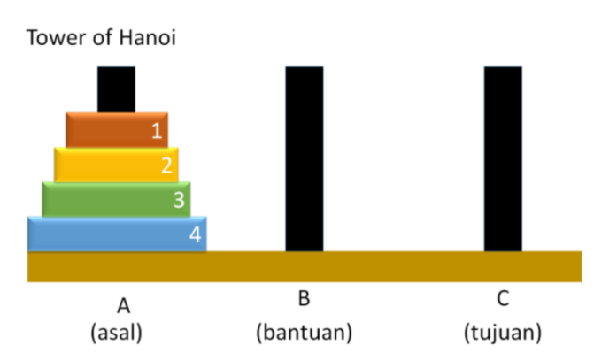

Mitos mengatakan bahwa, ketika tugas ini selesai, maka kuil akan lenyap dan dunia akan hilang. Tetapi ini hanya mitos saja, dan untuk memindahkan piringan emas satu persatu itu membutuhkan waktu milyaran tahun. Pemindahan piringan emas tersebut akan mudah, jika hanya 1 buah piringan saja yang akan dipindahkan.

Misalkan, terdapat 4 buah piringan terdapat di tiang 'A' dan akan dipindahkan ke tiang 'C', dan ada tiang 'B' sebagai bantuan. Untuk memindahkan 4 piringan tersebut dari tiang A ke tiang C, bukanlah hal yang mudah. Akan tetapi jika diasumsikan, bahwa 3 buah piringan teratas dapat dipindahkan secara langsung dari tiang A ke tiang B, maka piringan ke-4 dapat dengan mudah dipindahkan dari tiang A ke tiang C. Permasalahan berikutnya muncul adalah, bagaimana memindahkan 3 buah piringan dari tiang A ke tiang B. Hal ini dapat dengan mudah dilakukan jika dua buah piringan dapat dipindahkan dari tiang A ke tiang C, sehingga piringan ketiga dapat dipindahkan dari tiang A ke tiang B. Proses ini dapat dilakukan secara terus menerus hingga, hanya terdapat sebuah piringan saja yang akan dipindahkan dari satu tiang ke tiang lainnya (seperti halnya proses rekursif), seperti pada Gambar 4 berikut

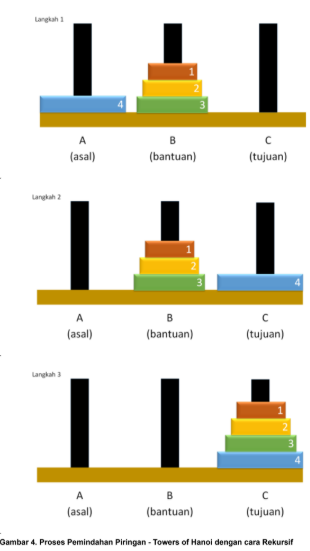

**Code**

Berikut code untuk penyelesaian permasalahan towers of hanoi dengan menggunakan teknik rekursif

```python
def towers(n,awal,bantuan,tujuan):
    if n==1:
        print("Piringan - 1 dari-", awal,"ke-",tujuan)
    else:
        towers(n-1,awal,tujuan,bantuan)
        print("Piringan -",n, "dari-",awal,"ke-", tujuan)
        towers(n-1,bantuan,awal,tujuan)

towers(4,'A','B','C')
```